# Testagem de COVID-19 em SP

Comparação de Modelos Preditivos

Bruno de Castro Paul Schultze, Lucas Bortolucci, Lucas Monteiro Bianchi, Luiz Afonso Glatzl Junior, Thiago Henrique Martinoni

12/11/2020

# Introdução

Durante a pandemia de Covid-19, ficou-se evidente a importância da testagem em massa, entretanto, muitos testes necessitam de equipamentos sofisticados e de execução especializada. Diante disso, os testes rápidos ganharam certa notoriedade e vem sendo largamente utilizados. Esses testes são geralmente sorológicos, capazes de identificar os anticorpos produzidos quando em contato com o antígeno. A metodologia mais utilizada por esse tipo de teste é o imunocromatografia, no qual, se consiste em produzir uma coloração através da reação entre o antígeno e o anticorpo, sendo capazes de detectar se o organismo esta porduzindo anticorpos (IgG e IgM). Embora as vantagens desse tipo de teste são claras, os testes rápidos possuem baixa sensibilidade. Podemos definir sensibilidade como a probabilidade do teste resultar em positivo quando o indíviduo de fato tem a doença. Em outras palavras, um teste com baixa sensibilidade pode resultar em um elevado número de falsos negativos, gerando estatísticas que não expressam a realidade e consequentemente dificultam o processo de tomada de decisões.

Recentemente, a vigilância da COVID-19, a infecção humana causada pelo novo Coronavírus, que vem causando uma pandemia, foi incorporada na rede de vigilância da Influenza e outros vírus respiratórios. Os dados são provenientes do site [openDataSUS](https://opendatasus.saude.gov.br/dataset/bd-srag-2020). Esta página tem como finalidade disponibilizar o legado dos banco de dados (BD) epidemiológicos de SRAG, da rede de vigilância da Influenza e outros vírus respiratórios, desde o início da sua implantação (2009) até os dias atuais (2020), com a incorporação da vigilância da COVID-19.

# Objetivos

- Identificar a capacidade de prevermos o resultado positivo de uma testagem para Covid-19
- Implementar e comparar diferentes modelos de classificação vistos na disciplina

# Preparação dos dados

## Dados

A população definida para esse estudo são pessoas residentes do estado de São Paulo cujo foram diagnosticadas com SRAG-Covid 19. Segundo o Ministério da Saúde, temos as seguintes definições:

Sindrome gripal (SG): Indivíduo com quadro respiratório agudo, caracterizado por pelo menos dois (2) dos seguintes sinais e sintomas: febre (mesmo que referida), calafrios, dor de garganta, dor de cabeça, tosse, coriza, distúrbios olfativos ou distúrbios gustativos. Observações:

- Em crianças: além dos itens anteriores considera-se também obstrução nasal, na ausência de outro diagnóstico específico.
- Em idosos: deve-se considerar também critérios específicos de agravamento como sincope, confusão mental, sonolência excessiva, irritabilidade e inapetência.
- Na suspeita de COVID-19, a febre pode estar ausente e sintomas gastrointestinais (diarreia) podem estar presentes.

Síndrome Respiratória Aguda Grave (SRAG): Indivíduo com SG que apresente: dispneia/desconforto respiratório OU pressão persistente no tórax OU saturação de $O_2$ menor que $95\%$ em ar ambiente OU coloração azulada dos lábios ou rosto.

Além disso, um caso de covid-19 pode ser confirmado por:

- Por critério clínico: Caso de SG ou SRAG com confirmação clínica associado a anosmia (disfunção olfativa) OU ageusia (disfunção gustatória) aguda sem outra causa pregressa.
- Por critério clínico-epidemiológico: Caso de SG ou SRAG com histórico de contato próximo ou domiciliar, nos 14 dias anteriores ao aparecimento dos sinais e sintomas com caso confirmado para COVID-19.
- Por critério clínico-imagem: Caso de SG ou SRAG ou óbito por SRAG que não foi possível confirmar por critério laboratorial E que apresente pelo menos uma (1) das seguintes alterações tomográficas: opacidade em vidro fosco (periférico ou multifocal) e sinal de halo reverso.

Observações: Em crianças: além dos itens anteriores, observar os batimentos de asa de nariz, cianose, tiragem intercostal, desidratação e inapetência; Para efeito de notificação no Sivep-Gripe, devem ser considerados os casos de SRAG hospitalizados ou os óbitos por SRAG independente de hospitalização.

## Carregando pacotes

Carregando pacotes do R.

## Importando o banco de dados

No código abaixo estamos importando os dados e aplicando os filtros necessárias paras as realizarmos as analises. Os dados utilizados podem ser baixados em [OpenDataSus](https://opendatasus.saude.gov.br/dataset/casos-nacionais).

```r
# Esse chunk é apenas para criar o banco de dados
# como demora um pouco, o resultado dessa saida foi salvo em dados.Rdata

# files <- dir() %>%
#   data.frame() %>%
#   filter(str_detect(.,"dados-sp-")) %>%
#   unlist() %>%
#   as.vector()
#
# dados <- NULL
# for(i in length(files)){
#   temp <- fread(files[i], header= TRUE, stringsAsFactors = T) %>%
#     filter(estadoIBGE == "35") %>%
#     filter(estado =="SÃO PAULO") %>%
#     filter(sexo %in% c("Masculino", "Feminino")) %>%
#     filter(resultadoTeste %in% c("Negativo", "Positivo")) %>%
#     filter(profissionalSaude %in% c("Não", "Sim")) %>%
#     mutate(
#       dataNotificacao = as.Date(substr(dataNotificacao,1,10), fmt = "%Y-%m-%d")
#     ) %>%
#     filter(dataNotificacao > lubridate::dmy("01-06-2020"))
#   dados <- rbind(dados,temp)
# }
# save(dados, file= "dados.Rdata")
```

```r
load("dados.Rdata")
#write.csv(dados, file="dados.csv")

# Criando os sintomeas
dados <- dados %>%
  mutate(
    resultadoTeste = factor(resultadoTeste, levels = c("Positivo", "Negativo")),
    profissionalSaude = factor(profissionalSaude, levels = c("Não", "Sim")),
    Assintomatico = as.factor(ifelse(grepl("Assintomático",sintomas),1,0)),
    Coriza = as.factor(ifelse(grepl("Coriza",sintomas),1,0)),
    Dispneia = as.factor(ifelse(grepl("Dispneia",sintomas),1,0)),
    DistGustativos = as.factor(ifelse(grepl("Distúrbios Gustativos",sintomas),1,0)),
    DistOlfativos = as.factor(ifelse(grepl("Distúrbios Olfativos",sintomas),1,0)),
    DorDeCabeca = as.factor(ifelse(grepl("Dor de Cabeça",sintomas),1,0)),
    DorDeGarganta = as.factor(ifelse(grepl("Dor de Garganta",sintomas),1,0)),
    Febre = as.factor(ifelse(grepl("Febre",sintomas),1,0)),
    Tosse = as.factor(ifelse(grepl("Tosse",sintomas),1,0)),
    Outros = as.factor(ifelse(grepl("Outros",sintomas),1,0)),
    verificacao =
      as.numeric(Coriza) + as.numeric(Dispneia) + as.numeric(DistGustativos) +
      as.numeric(DistOlfativos) + as.numeric(DorDeCabeca) + as.numeric(DorDeGarganta) + as.numeric(Febre) + as.numeric(Tosse) + as.numeric(Outros),
    verificacao2 = case_when(
      Assintomatico == 1 & verificacao >= 1 ~ 1,
      TRUE ~ 0
    ),
    tipoTeste =  case_when(
      grepl("RÁPIDO",tipoTeste) == TRUE ~ "Teste rápido",
      grepl("RT-PCR",tipoTeste) == TRUE ~ "RT-PCR",
      TRUE ~ "Outro"
    ),
    idade = as.integer(as.character(idade)),
    faixaetaria = cut(idade,
                      breaks = c(seq(0,60,10),Inf), right = F,include.lowest = T,
                      levels = c("0 a 9", "10 a 19", "20 a 29", "30 a 39", "40 a 49", "50 a 59", ">= 60"))
  ) %>%
  filter(verificacao2 !=1) %>%
  filter(tipoTeste != "Outro") %>%
  filter(idade <= 100) %>%
  dplyr::select(-c(verificacao,verificacao2))

dados$resultadoTeste = relevel(dados$resultadoTeste, ref = 'Negativo')
# Selecionando apenas as informações que serão utilizadas
dados.modelo <- dados %>%
  filter(tipoTeste == "RT-PCR") %>%
  dplyr::select(resultadoTeste, sexo, faixaetaria, idade,
                Assintomatico,Coriza, Dispneia , DistGustativos,
                DistOlfativos, DorDeCabeca, DorDeGarganta,
                Febre, Tosse, Outros, profissionalSaude, dataNotificacao)

# Separar os dados de RT-PCR temporalmente, e os de teste serao os de teste rápido
dados.modelo <- dados.modelo[order(as.Date(dados.modelo$dataNotificacao, format="%Y-%m-%d")),] %>% dplyr::select(-dataNotificacao)
index_max <- (3*nrow(dados.modelo))%/%4 + 1
dados.treino <- dados.modelo[1:index_max]
dados.valid <- dados.modelo[(index_max+1):nrow(dados.modelo)]
dados.test <- dados %>%
  filter(tipoTeste != "RT-PCR") %>%
  dplyr::select(resultadoTeste, sexo, faixaetaria, idade,
                Assintomatico, Coriza, Dispneia , DistGustativos,
                DistOlfativos, DorDeCabeca, DorDeGarganta,
                Febre, Tosse, Outros, profissionalSaude)

# Apgando objetos desnecessarios
rm(dados, dados.modelo, index_max)
```

```r
fatores <- colnames(dados.treino)[c(1:2,7:16)]

variaveis <- colnames(dados.treino)[c(2,5,7:16)]

## Criando a tabela 1 - Treino
tableOne.treino <- CreateTableOne(vars = variaveis, strata = "resultadoTeste", data = dados.treino, factorVars = fatores, addOverall = T)
tabela1.treino <- print(tableOne.treino, showAllLevels = T, test = F, catDigits = 2,printToggle = F)
```

A tabela abaixo apresenta as características e sintomas dos individuos que integram o conjunto de dados de treinamento.

```r
tabela1.treino %>%
  knitr::kable(caption = "Estatística descritiva para cada características e sintomas dos indivíduos que compõem o conjunto de treinamento.", format = "html") %>%
  kableExtra::kable_styling() %>%
  kableExtra::kable_classic_2(full_width = F)
```

Estatística descritiva para cada características e sintomas dos indivíduos que compõem o conjunto de treinamento.

|  | level | Overall | Negativo | Positivo |
| --- | --- | --- | --- | --- |
| n |  | 212665 | 136921 | 75744 |
| sexo (%) | Feminino | 121371 ( 57.07) | 80253 ( 58.61) | 41118 ( 54.29) |
|  | Masculino | 91294 ( 42.93) | 56668 ( 41.39) | 34626 ( 45.71) |
| Assintomatico (%) | 0 | 212665 (100.00) | 136921 (100.00) | 75744 (100.00) |
|  | 1 | 0 ( 0.00) | 0 ( 0.00) | 0 ( 0.00) |
| Dispneia (%) | 0 | 172018 ( 80.89) | 109029 ( 79.63) | 62989 ( 83.16) |
|  | 1 | 40647 ( 19.11) | 27892 ( 20.37) | 12755 ( 16.84) |
| DistGustativos (%) | 0 | 192381 ( 90.46) | 128287 ( 93.69) | 64094 ( 84.62) |
|  | 1 | 20284 ( 9.54) | 8634 ( 6.31) | 11650 ( 15.38) |
| DistOlfativos (%) | 0 | 195248 ( 91.81) | 130376 ( 95.22) | 64872 ( 85.65) |
|  | 1 | 17417 ( 8.19) | 6545 ( 4.78) | 10872 ( 14.35) |
| DorDeCabeca (%) | 0 | 148493 ( 69.82) | 94391 ( 68.94) | 54102 ( 71.43) |
|  | 1 | 64172 ( 30.18) | 42530 ( 31.06) | 21642 ( 28.57) |
| DorDeGarganta (%) | 0 | 129895 ( 61.08) | 80103 ( 58.50) | 49792 ( 65.74) |
|  | 1 | 82770 ( 38.92) | 56818 ( 41.50) | 25952 ( 34.26) |
| Febre (%) | 0 | 136274 ( 64.08) | 92669 ( 67.68) | 43605 ( 57.57) |
|  | 1 | 76391 ( 35.92) | 44252 ( 32.32) | 32139 ( 42.43) |
| Tosse (%) | 0 | 94403 ( 44.39) | 62770 ( 45.84) | 31633 ( 41.76) |
|  | 1 | 118262 ( 55.61) | 74151 ( 54.16) | 44111 ( 58.24) |
| Outros (%) | 0 | 98989 ( 46.55) | 64560 ( 47.15) | 34429 ( 45.45) |
|  | 1 | 113676 ( 53.45) | 72361 ( 52.85) | 41315 ( 54.55) |
| profissionalSaude (%) | Não | 198576 ( 93.38) | 127548 ( 93.15) | 71028 ( 93.77) |
|  | Sim | 14089 ( 6.62) | 9373 ( 6.85) | 4716 ( 6.23) |

```r
## Criando a tabela 1 - Validacao
tableOne.valid <- CreateTableOne(vars = variaveis, strata = "resultadoTeste", data = dados.valid, factorVars = fatores, addOverall = T)
tabela1.valid <- print(tableOne.valid, showAllLevels = T, test = F, catDigits = 2,printToggle = F)
```

```r
tabela1.valid %>%
  knitr::kable(caption = "Estatística descritiva para cada características e sintomas dos indivíduos que compõem o conjunto de validação.", format = "html") %>%
  kableExtra::kable_styling() %>%
  kableExtra::kable_classic_2(full_width = F)
```

Estatística descritiva para cada características e sintomas dos indivíduos que compõem o conjunto de validação.

|  | level | Overall | Negativo | Positivo |
| --- | --- | --- | --- | --- |
| n |  | 70887 | 48528 | 22359 |
| sexo (%) | Feminino | 40002 ( 56.43) | 27941 ( 57.58) | 12061 ( 53.94) |
|  | Masculino | 30885 ( 43.57) | 20587 ( 42.42) | 10298 ( 46.06) |
| Assintomatico (%) | 0 | 70887 (100.00) | 48528 (100.00) | 22359 (100.00) |
|  | 1 | 0 ( 0.00) | 0 ( 0.00) | 0 ( 0.00) |
| Dispneia (%) | 0 | 58648 ( 82.73) | 39636 ( 81.68) | 19012 ( 85.03) |
|  | 1 | 12239 ( 17.27) | 8892 ( 18.32) | 3347 ( 14.97) |
| DistGustativos (%) | 0 | 61706 ( 87.05) | 44544 ( 91.79) | 17162 ( 76.76) |
|  | 1 | 9181 ( 12.95) | 3984 ( 8.21) | 5197 ( 23.24) |
| DistOlfativos (%) | 0 | 62904 ( 88.74) | 45448 ( 93.65) | 17456 ( 78.07) |
|  | 1 | 7983 ( 11.26) | 3080 ( 6.35) | 4903 ( 21.93) |
| DorDeCabeca (%) | 0 | 41447 ( 58.47) | 28400 ( 58.52) | 13047 ( 58.35) |
|  | 1 | 29440 ( 41.53) | 20128 ( 41.48) | 9312 ( 41.65) |
| DorDeGarganta (%) | 0 | 42623 ( 60.13) | 27948 ( 57.59) | 14675 ( 65.63) |
|  | 1 | 28264 ( 39.87) | 20580 ( 42.41) | 7684 ( 34.37) |
| Febre (%) | 0 | 46434 ( 65.50) | 33080 ( 68.17) | 13354 ( 59.73) |
|  | 1 | 24453 ( 34.50) | 15448 ( 31.83) | 9005 ( 40.27) |
| Tosse (%) | 0 | 33373 ( 47.08) | 23259 ( 47.93) | 10114 ( 45.23) |
|  | 1 | 37514 ( 52.92) | 25269 ( 52.07) | 12245 ( 54.77) |
| Outros (%) | 0 | 38435 ( 54.22) | 26318 ( 54.23) | 12117 ( 54.19) |
|  | 1 | 32452 ( 45.78) | 22210 ( 45.77) | 10242 ( 45.81) |
| profissionalSaude (%) | Não | 67489 ( 95.21) | 46133 ( 95.06) | 21356 ( 95.51) |
|  | Sim | 3398 ( 4.79) | 2395 ( 4.94) | 1003 ( 4.49) |

A tabela abaixo apresenta os “resultados” obtidos através do uso do teste rápido. É importante ressaltar que mesmo tendo os “resultados” para o banco de teste, este trabalho desconsidera essa informação, visto que este tipo de teste é menos confiavel que o teste RT-PCR. De toda forma, essa informação é relevante para comparar com o cenário onde todos os individuos do banco teste teriam realizado o RT-PCR ao invés do teste rápido, permitindo desta forma, obter uma estimativa do quanto o teste rápido, possívelmente, submestiou os casos positivos de covid-19.

```r
prop.table(table(dados.test$resultadoTeste)) %>%
  knitr::kable(caption = "Proporção dos resultados obtidos utilizando o teste rápido para Covid-19 (banco teste).", format = "html") %>%
  kableExtra::kable_styling() %>%
  kableExtra::kable_classic_2(full_width = F)
```

Proporção dos resultados obtidos utilizando o teste rápido para Covid-19 (banco teste).

| Var1 | Freq |
| --- | --- |
| Negativo | 0.7425741 |
| Positivo | 0.2574259 |

```r
# Removendo os assintomaticos do conjunto treinamento, validação e teste
# pois essa variavel é colinear quando considerados todos os demais sintomas
dados.treino <- dados.treino %>% dplyr::select(-Assintomatico)
dados.valid  <-dados.valid %>% dplyr::select(-Assintomatico)
dados.test <- dados.test %>% dplyr::select(-Assintomatico)
```

# Metodologias

Nesta seção é apresentado o conjunto de metodologias empregadas para classificar, segundo os sintomas, se a pessoa é positivo ou negativo para covid-19.

## Métricas de qualidade dos modelos

Foram utilizadas as seguintes métricas

- Sensibilidade: Probabilidade do resultado ser positivo quando de fato o individuo tem a doença.
- Especificidade: Probabilidade do resultado ser negativo quando de fato o individuo não tem a doença.
- Acurácia: probabilidade do teste fornecer resultados corretos, ou seja, ser positivo nos doentes e negativo nos não doentes. Expresso de outra forma é a probabilidade dos verdadeiros positivos e verdadeiros negativos como uma proporção de todos osresultados

Para esse estudo, ao invés de considerarmos o “individuo ter ou não ter a doença”, teremos “o teste RT-PCR positivo ou negativo”, ficando a reinterpretação da sensibilidade e especificidade dessas métricas conforme abaixo:

- Sensibilidade: Probabilidade do modelo resultar em positivo quando o teste RT-PCR foi positivo.
- Especificidade: Probabilidade do modelo resultar em negativo quando o teste RT-PCR foi negativo.

## Regressão Logística

Aqui, assumimos que o resultado do teste dadas as variáveis explicativas, $Y|x_i$, assume uma distribuição $Bernoulli$ com probabilidade $\pi_i$ de ser positivo.
$$Y|x_i \sim Bernoulli(\pi_i)$$
Além disso, a função de ligação é:
$$\log\left(\frac{\pi_i}{1 - \pi_i}\right) = \beta_0 + \beta_1x_1 + \beta_2x_2 + ... + + \beta_{13}x_{13}$$

Primeiro vamos considerar o modelo completo contendo como variáveis explicativas:

- Profissional da saúde
- Faixa Etária
- Idade
- Sexo
- Sintomas (uma variável indicadora para cada)

```r
fit.rl = glm(resultadoTeste ~ ., family = binomial,data = dados.treino)
summary(fit.rl)
```

```
##
## Call:
## glm(formula = resultadoTeste ~ ., family = binomial, data = dados.treino)
##
## Deviance Residuals:
##     Min       1Q   Median       3Q      Max
## -1.9885  -0.9231  -0.7585   1.2661   2.2885
##
## Coefficients:
##                       Estimate Std. Error z value             Pr(>|z|)
## (Intercept)          -1.776547   0.031964 -55.580 < 0.0000000000000002 ***
## sexoMasculino         0.150314   0.009568  15.709 < 0.0000000000000002 ***
## faixaetaria[10,20)    0.542912   0.038044  14.271 < 0.0000000000000002 ***
## faixaetaria[20,30)    0.543762   0.039993  13.596 < 0.0000000000000002 ***
## faixaetaria[30,40)    0.769901   0.048037  16.027 < 0.0000000000000002 ***
## faixaetaria[40,50)    0.805843   0.057445  14.028 < 0.0000000000000002 ***
## faixaetaria[50,60)    0.898586   0.068126  13.190 < 0.0000000000000002 ***
## faixaetaria[60,Inf]   0.766303   0.084743   9.043 < 0.0000000000000002 ***
## idade                 0.004391   0.001193   3.679             0.000234 ***
## Coriza1              -0.256682   0.012323 -20.829 < 0.0000000000000002 ***
## Dispneia1            -0.318016   0.012334 -25.783 < 0.0000000000000002 ***
## DistGustativos1       0.492395   0.021047  23.395 < 0.0000000000000002 ***
## DistOlfativos1        0.980779   0.022587  43.423 < 0.0000000000000002 ***
## DorDeCabeca1         -0.153650   0.010749 -14.295 < 0.0000000000000002 ***
## DorDeGarganta1       -0.301171   0.009978 -30.185 < 0.0000000000000002 ***
## Febre1                0.493495   0.009810  50.308 < 0.0000000000000002 ***
## Tosse1                0.233627   0.009806  23.824 < 0.0000000000000002 ***
## Outros1               0.118902   0.009843  12.079 < 0.0000000000000002 ***
## profissionalSaudeSim -0.054746   0.019306  -2.836             0.004573 **
## ---
## Signif. codes:  0 '***' 0.001 '**' 0.01 '*' 0.05 '.' 0.1 ' ' 1
##
## (Dispersion parameter for binomial family taken to be 1)
##
##     Null deviance: 276966  on 212664  degrees of freedom
## Residual deviance: 262592  on 212646  degrees of freedom
## AIC: 262630
##
## Number of Fisher Scoring iterations: 4
```

### Seleção do Modelo

Vamos usar stepAIC para tentar escolher um subconjunto das variáveis explicativas.

```r
fit.rl = stepAIC(fit.rl, direction = 'both', trace = 0)
summary(fit.rl)
```

```
##
## Call:
## glm(formula = resultadoTeste ~ sexo + faixaetaria + idade + Coriza +
##     Dispneia + DistGustativos + DistOlfativos + DorDeCabeca +
##     DorDeGarganta + Febre + Tosse + Outros + profissionalSaude,
##     family = binomial, data = dados.treino)
##
## Deviance Residuals:
##     Min       1Q   Median       3Q      Max
## -1.9885  -0.9231  -0.7585   1.2661   2.2885
##
## Coefficients:
##                       Estimate Std. Error z value             Pr(>|z|)
## (Intercept)          -1.776547   0.031964 -55.580 < 0.0000000000000002 ***
## sexoMasculino         0.150314   0.009568  15.709 < 0.0000000000000002 ***
## faixaetaria[10,20)    0.542912   0.038044  14.271 < 0.0000000000000002 ***
## faixaetaria[20,30)    0.543762   0.039993  13.596 < 0.0000000000000002 ***
## faixaetaria[30,40)    0.769901   0.048037  16.027 < 0.0000000000000002 ***
## faixaetaria[40,50)    0.805843   0.057445  14.028 < 0.0000000000000002 ***
## faixaetaria[50,60)    0.898586   0.068126  13.190 < 0.0000000000000002 ***
## faixaetaria[60,Inf]   0.766303   0.084743   9.043 < 0.0000000000000002 ***
## idade                 0.004391   0.001193   3.679             0.000234 ***
## Coriza1              -0.256682   0.012323 -20.829 < 0.0000000000000002 ***
## Dispneia1            -0.318016   0.012334 -25.783 < 0.0000000000000002 ***
## DistGustativos1       0.492395   0.021047  23.395 < 0.0000000000000002 ***
## DistOlfativos1        0.980779   0.022587  43.423 < 0.0000000000000002 ***
## DorDeCabeca1         -0.153650   0.010749 -14.295 < 0.0000000000000002 ***
## DorDeGarganta1       -0.301171   0.009978 -30.185 < 0.0000000000000002 ***
## Febre1                0.493495   0.009810  50.308 < 0.0000000000000002 ***
## Tosse1                0.233627   0.009806  23.824 < 0.0000000000000002 ***
## Outros1               0.118902   0.009843  12.079 < 0.0000000000000002 ***
## profissionalSaudeSim -0.054746   0.019306  -2.836             0.004573 **
## ---
## Signif. codes:  0 '***' 0.001 '**' 0.01 '*' 0.05 '.' 0.1 ' ' 1
##
## (Dispersion parameter for binomial family taken to be 1)
##
##     Null deviance: 276966  on 212664  degrees of freedom
## Residual deviance: 262592  on 212646  degrees of freedom
## AIC: 262630
##
## Number of Fisher Scoring iterations: 4
```

Todas as variáveis foram mantidas pelo algoritmo. Vamos então checar por multicolinearidade.

```r
car::vif(fit.rl)
```

```
##                        GVIF Df GVIF^(1/(2*Df))
## sexo               1.026810  1        1.013316
## faixaetaria       18.714348  6        1.276482
## idade             17.966002  1        4.238632
## Coriza             1.074528  1        1.036594
## Dispneia           1.023820  1        1.011840
## DistGustativos     1.814785  1        1.347140
## DistOlfativos      1.817173  1        1.348026
## DorDeCabeca        1.081349  1        1.039879
## DorDeGarganta      1.053246  1        1.026278
## Febre              1.036171  1        1.017925
## Tosse              1.072933  1        1.035825
## Outros             1.093049  1        1.045490
## profissionalSaude  1.032012  1        1.015880
```

Notemos que há evidências de multicolinearidade usando os critérios usuais (VIF maiores que 5), então retiraremos *idade* do modelo.

```r
fit.rl = glm(resultadoTeste ~ ., family = binomial,data = subset(dados.treino, select = -idade))
summary(fit.rl)
```

```
##
## Call:
## glm(formula = resultadoTeste ~ ., family = binomial, data = subset(dados.treino,
##     select = -idade))
##
## Deviance Residuals:
##     Min       1Q   Median       3Q      Max
## -1.9604  -0.9254  -0.7597   1.2651   2.2842
##
## Coefficients:
##                       Estimate Std. Error z value             Pr(>|z|)
## (Intercept)          -1.758550   0.031587 -55.673 < 0.0000000000000002 ***
## sexoMasculino         0.149936   0.009568  15.671 < 0.0000000000000002 ***
## faixaetaria[10,20)    0.596746   0.035124  16.990 < 0.0000000000000002 ***
## faixaetaria[20,30)    0.635299   0.031322  20.283 < 0.0000000000000002 ***
## faixaetaria[30,40)    0.904819   0.031044  29.146 < 0.0000000000000002 ***
## faixaetaria[40,50)    0.982872   0.031400  31.302 < 0.0000000000000002 ***
## faixaetaria[50,60)    1.119449   0.032234  34.728 < 0.0000000000000002 ***
## faixaetaria[60,Inf]   1.054347   0.032388  32.553 < 0.0000000000000002 ***
## Coriza1              -0.257096   0.012322 -20.864 < 0.0000000000000002 ***
## Dispneia1            -0.316857   0.012329 -25.700 < 0.0000000000000002 ***
## DistGustativos1       0.492322   0.021047  23.392 < 0.0000000000000002 ***
## DistOlfativos1        0.980232   0.022587  43.399 < 0.0000000000000002 ***
## DorDeCabeca1         -0.154592   0.010745 -14.387 < 0.0000000000000002 ***
## DorDeGarganta1       -0.302313   0.009972 -30.316 < 0.0000000000000002 ***
## Febre1                0.492841   0.009807  50.252 < 0.0000000000000002 ***
## Tosse1                0.233660   0.009806  23.828 < 0.0000000000000002 ***
## Outros1               0.118561   0.009842  12.046 < 0.0000000000000002 ***
## profissionalSaudeSim -0.055013   0.019307  -2.849              0.00438 **
## ---
## Signif. codes:  0 '***' 0.001 '**' 0.01 '*' 0.05 '.' 0.1 ' ' 1
##
## (Dispersion parameter for binomial family taken to be 1)
##
##     Null deviance: 276966  on 212664  degrees of freedom
## Residual deviance: 262605  on 212647  degrees of freedom
## AIC: 262641
##
## Number of Fisher Scoring iterations: 4
```

Com o modelo definido, partiremos então para a definição do ponto de corte. Para isso levaremos em conta principalmente Sensibilidade, mas também Especificidade e Acurácia Total. Para definir o ponto de corte utilizaremos os dados de treino mesmo.

```r
pred.rl.treino = predict(fit.rl, type = 'response')
```

Abaixo podemos ver a curva ROC:

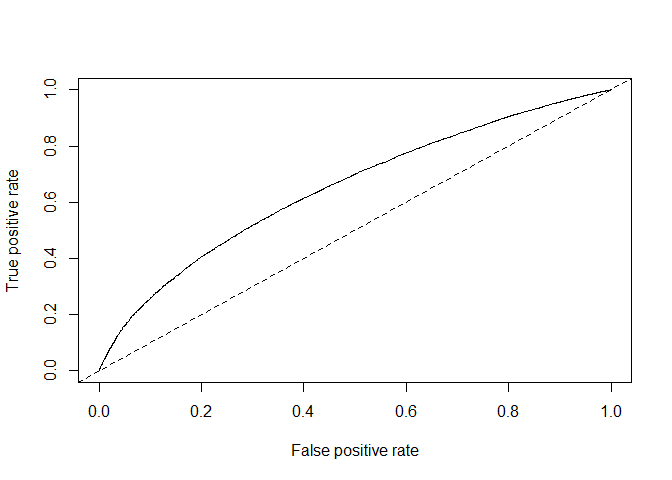

```r
pr.train = ROCR::prediction(pred.rl.treino, dados.treino$resultadoTeste)
pr.train.perf = ROCR::performance(pr.train, measure = 'tpr', x.measure = 'fpr')
plot(pr.train.perf)
abline(a=0.0, b= 1.0, lty = 2)
```

Vamos checar também a área embaixo da curva (AUC) que criamos anteriormente.

```r
ROCR::performance(pr.train, measure = 'auc')@y.values[[1]]
```

```
## [1] 0.6505379
```

Agora vamos escolher o threshold. Para isso primeiro vamos definir o “custo” de um erro de forma heterogênea: um Falso Negativo será maior que o peso de um Falso Positivo. Isso se dá pois é pior dizer para um paciente infectado que ele não está com COVID (pois isso fará com que ele não obedeça o isolamento social e a quarentena de forma tão incisiva) do que dizer para uma pessoa não-infectada que ela está com COVID (pois isso somente fará com que ela realize exames adicionais que mostrarão que a mesma não está infectada). Não alteraremos a prevalência dado que não temos o conhecimento técnico epidemiológico para tal decisão. Para a escolha do threshold usaremos o critério de Youden com uma modificação proposta por Perkins e Schisterman, dado por:
$$max(sensitivities + r \times specificities)$$
Onde:
$$r = \frac{1 - prevalence}{cost * prevalence}$$
Sendo *cost* o custo relativo de um Falso Negativo comparado com o de um Falso Positivo e prevalence número de Positivos dividido pelo total.

```r
prop.table(table(dados.treino$resultadoTeste))
```

```
##
##  Negativo  Positivo
## 0.6438342 0.3561658
```

### Comparação variando Custo

Para comparar e escolher o custo, testaremos duas possibilidades ($custo = 2$ e $custo = 3$), e escolheremos o custo cujo threshold maximiza a sensibilidade nos dados de treino.

Primeiro, testaremos com $custo = 2$.

```r
custo = 2
prevalencia = 0.3561658
rl.ROC <- roc(dados.treino$resultadoTeste, pred.rl.treino,plot=FALSE)
thre = as.numeric(coords(rl.ROC, "best", ret = "threshold", best.weights = c(cost = custo, prevalence =  prevalencia)))
thre
```

```
## [1] 0.3462531
```

Agora, com o *threshold* definido, veremos então a matriz de confusão com relação aos dados de treino.

```r
rl.treino = as.factor(ifelse(pred.rl.treino > thre,'Positivo',"Negativo"))
confusionMatrix(rl.treino, reference = dados.treino$resultadoTeste, positive = 'Positivo')
```

```
## Confusion Matrix and Statistics
##
##           Reference
## Prediction Negativo Positivo
##   Negativo    83151    29650
##   Positivo    53770    46094
##
##                Accuracy : 0.6077
##                  95% CI : (0.6057, 0.6098)
##     No Information Rate : 0.6438
##     P-Value [Acc > NIR] : 1
##
##                   Kappa : 0.2015
##
##  Mcnemar's Test P-Value : <0.0000000000000002
##
##             Sensitivity : 0.6085
##             Specificity : 0.6073
##          Pos Pred Value : 0.4616
##          Neg Pred Value : 0.7371
##              Prevalence : 0.3562
##          Detection Rate : 0.2167
##    Detection Prevalence : 0.4696
##       Balanced Accuracy : 0.6079
##
##        'Positive' Class : Positivo
##
```

O modelo conseguiu classificar corretamente $61\%$ (sensibilidade) das pessoas que tiveram resultado positivo no exame, e classificou corretamente $61\%$ das pessoas que tiveram resultado negativo.

Agora, com custo = 3:

```r
custo = 3
prevalencia = 0.3561658
rl.ROC <- roc(dados.treino$resultadoTeste, pred.rl.treino,plot=FALSE)
thre = as.numeric(coords(rl.ROC, "best", ret = "threshold", best.weights = c(cost = custo, prevalence =  prevalencia)))
thre
```

```
## [1] 0.2507847
```

Notemos que, como esperado, o threshold diminuiu. Veremos então a matriz de confusão com relação aos dados de treino.

```r
rl.treino = as.factor(ifelse(pred.rl.treino > thre,'Positivo',"Negativo"))
confusionMatrix(rl.treino, reference = dados.treino$resultadoTeste, positive = 'Positivo')
```

```
## Confusion Matrix and Statistics
##
##           Reference
## Prediction Negativo Positivo
##   Negativo    30634     8232
##   Positivo   106287    67512
##
##                Accuracy : 0.4615
##                  95% CI : (0.4594, 0.4636)
##     No Information Rate : 0.6438
##     P-Value [Acc > NIR] : 1
##
##                   Kappa : 0.0892
##
##  Mcnemar's Test P-Value : <0.0000000000000002
##
##             Sensitivity : 0.8913
##             Specificity : 0.2237
##          Pos Pred Value : 0.3884
##          Neg Pred Value : 0.7882
##              Prevalence : 0.3562
##          Detection Rate : 0.3175
##    Detection Prevalence : 0.8172
##       Balanced Accuracy : 0.5575
##
##        'Positive' Class : Positivo
##
```

O modelo conseguiu classificar corretamente $89\%$ (sensibilidade) das pessoas que tiveram resultado positivo no exame, e classificou corretamente $22\%$ das pessoas que tiveram resultado negativo.

Escolheremos então $custo = 3$ pois, apesar de diminuir a especificidade, maximizou a capacidade do algoritmo de detectar positivos verdadeiros.

### Avaliação do Modelo Final

Vamos checar as métricas agora olhando para os dados de validação (que são como nossos dados de teste).

```r
pred.rl.val = predict(fit.rl, newdata = dados.valid, type = 'response')
rl.val <- as.factor(ifelse(pred.rl.val > thre,"Positivo","Negativo"))
confusionMatrix(rl.val, reference = dados.valid$resultadoTeste, positive = 'Positivo')
```

```
## Confusion Matrix and Statistics
##
##           Reference
## Prediction Negativo Positivo
##   Negativo    13238     2993
##   Positivo    35290    19366
##
##                Accuracy : 0.4599
##                  95% CI : (0.4563, 0.4636)
##     No Information Rate : 0.6846
##     P-Value [Acc > NIR] : 1
##
##                   Kappa : 0.1
##
##  Mcnemar's Test P-Value : <0.0000000000000002
##
##             Sensitivity : 0.8661
##             Specificity : 0.2728
##          Pos Pred Value : 0.3543
##          Neg Pred Value : 0.8156
##              Prevalence : 0.3154
##          Detection Rate : 0.2732
##    Detection Prevalence : 0.7710
##       Balanced Accuracy : 0.5695
##
##        'Positive' Class : Positivo
##
```

```r
pred.rl.test = predict(fit.rl, newdata = dados.test %>% dplyr::select(-resultadoTeste), type = 'response')
rl.test = as.factor(ifelse(pred.rl.test > thre,'Positivo',"Negativo"))
confusionMatrix(rl.test, reference = dados.test$resultadoTeste, positive = 'Positivo')
```

```
## Confusion Matrix and Statistics
##
##           Reference
## Prediction Negativo Positivo
##   Negativo    24114     5429
##   Positivo   105209    39403
##
##                Accuracy : 0.3647
##                  95% CI : (0.3625, 0.367)
##     No Information Rate : 0.7426
##     P-Value [Acc > NIR] : 1
##
##                   Kappa : 0.0378
##
##  Mcnemar's Test P-Value : <0.0000000000000002
##
##             Sensitivity : 0.8789
##             Specificity : 0.1865
##          Pos Pred Value : 0.2725
##          Neg Pred Value : 0.8162
##              Prevalence : 0.2574
##          Detection Rate : 0.2263
##    Detection Prevalence : 0.8304
##       Balanced Accuracy : 0.5327
##
##        'Positive' Class : Positivo
##
```

Notemos, então, que a sensibilidade nos dados de teste foi de $88\%$ e a especificidade de $19\%$. Apesar das métricas de teste terem sido parecidas, convem lembrar que não podemos usar as mesmas para avaliação do modelo pois os testes laboratoriais utilizados nas amostras não são tão confiáveis.

A proporção prevista para a base de testes foi:

```r
prop.table(table(rl.test))
```

```
## rl.test
##  Negativo  Positivo
## 0.1696362 0.8303638
```

Por fim, criaremos um vetor que resume as métricas utilizadas nos três conjuntos de dados.

```r
Acurácia = c(46.15, 45.99, 36.47)
Sensibilidade = c(89.13, 86.61, 87.89)
Especificidade = c(22.37, 27.28, 18.65)
med_rl = cbind(Acurácia, Sensibilidade, Especificidade)
rownames(med_rl) = c('Treino', 'Validação', 'Teste')
med_rl %>%
  knitr::kable(caption = "Métricas de qualidade do modelo logistico.", format = "html") %>%
  kableExtra::kable_styling() %>%
  kableExtra::kable_classic_2(full_width = F)
```

Métricas de qualidade do modelo logistico.

|  | Acurácia | Sensibilidade | Especificidade |
| --- | --- | --- | --- |
| Treino | 46.15 | 89.13 | 22.37 |
| Validação | 45.99 | 86.61 | 27.28 |
| Teste | 36.47 | 87.89 | 18.65 |

E o tempo de execução do *fit* é:

```r
tic('RL fitting')
fit.rl2 = glm(resultadoTeste ~ ., family = binomial,data = dados.treino %>% dplyr::select(-idade))
toc()
```

```
## RL fitting: 1.5 sec elapsed
```